# Modelos uni y multinivel

Hector Najera

22/05/2025

# Introducción

Esta nota brinda una introducción bastante elemental a los siguientes tipos de modelos:

- Modelación no multinivel
- Modelación multinivel: Ordenadas al origen
- Modelación multinivel: Ordenadas al origen y pendientes

También se aborda el cómputo de los estadísticos de validación cruzada: loo

```r
library(pacman)
p_load(haven, dplyr, brms, bayesplot, tidybayes, ggplot2)
color_scheme_set(scheme = "viridis")
```

```r
D<-read_dta("pobreza_18.dta")
```

# Modelo multinivel y no multinivel

## Modelo de un nivel

Vamos a utilizar datos de la ENIGH 2018. Usaremos el nivel educativo, el tamaño del hogar y el de localidad como variables de ajuste. Además ajustaremos el modelo por la entidad federativa de residencia.

```r
M<-brm(pobreza ~ 1 + factor(niv_edexpjh),
        prior = c(set_prior("normal(0,10)", class = "b")),
        family="bernoulli", chains=4, cores=4, iter=2000,  threads = threading(14, grainsize = 100),backend = "cmdstanr", data=D)
```

```
## Running MCMC with 4 parallel chains, with 14 thread(s) per chain...
##
## Chain 1 Iteration:    1 / 2000 [  0%]  (Warmup)
## Chain 1 Iteration:  100 / 2000 [  5%]  (Warmup)
## Chain 1 Iteration:  200 / 2000 [ 10%]  (Warmup)
## Chain 1 Iteration:  300 / 2000 [ 15%]  (Warmup)
## Chain 1 Iteration:  400 / 2000 [ 20%]  (Warmup)
## Chain 1 Iteration:  500 / 2000 [ 25%]  (Warmup)
## Chain 1 Iteration:  600 / 2000 [ 30%]  (Warmup)
## Chain 1 Iteration:  700 / 2000 [ 35%]  (Warmup)
## Chain 1 Iteration:  800 / 2000 [ 40%]  (Warmup)
## Chain 1 Iteration:  900 / 2000 [ 45%]  (Warmup)
## Chain 1 Iteration: 1000 / 2000 [ 50%]  (Warmup)
## Chain 1 Iteration: 1001 / 2000 [ 50%]  (Sampling)
## Chain 1 Iteration: 1100 / 2000 [ 55%]  (Sampling)
## Chain 1 Iteration: 1200 / 2000 [ 60%]  (Sampling)
## Chain 1 Iteration: 1300 / 2000 [ 65%]  (Sampling)
## Chain 1 Iteration: 1400 / 2000 [ 70%]  (Sampling)
## Chain 1 Iteration: 1500 / 2000 [ 75%]  (Sampling)
## Chain 1 Iteration: 1600 / 2000 [ 80%]  (Sampling)
## Chain 1 Iteration: 1700 / 2000 [ 85%]  (Sampling)
## Chain 1 Iteration: 1800 / 2000 [ 90%]  (Sampling)
## Chain 1 Iteration: 1900 / 2000 [ 95%]  (Sampling)
## Chain 1 Iteration: 2000 / 2000 [100%]  (Sampling)
## Chain 2 Iteration:    1 / 2000 [  0%]  (Warmup)
## Chain 2 Iteration:  100 / 2000 [  5%]  (Warmup)
## Chain 2 Iteration:  200 / 2000 [ 10%]  (Warmup)
## Chain 2 Iteration:  300 / 2000 [ 15%]  (Warmup)
## Chain 2 Iteration:  400 / 2000 [ 20%]  (Warmup)
## Chain 2 Iteration:  500 / 2000 [ 25%]  (Warmup)
## Chain 2 Iteration:  600 / 2000 [ 30%]  (Warmup)
## Chain 2 Iteration:  700 / 2000 [ 35%]  (Warmup)
## Chain 2 Iteration:  800 / 2000 [ 40%]  (Warmup)
## Chain 2 Iteration:  900 / 2000 [ 45%]  (Warmup)
## Chain 2 Iteration: 1000 / 2000 [ 50%]  (Warmup)
## Chain 2 Iteration: 1001 / 2000 [ 50%]  (Sampling)
## Chain 2 Iteration: 1100 / 2000 [ 55%]  (Sampling)
## Chain 2 Iteration: 1200 / 2000 [ 60%]  (Sampling)
## Chain 2 Iteration: 1300 / 2000 [ 65%]  (Sampling)
## Chain 2 Iteration: 1400 / 2000 [ 70%]  (Sampling)
```

[output cut: 43 more lines]

```
## Chain 4 Iteration: 1100 / 2000 [ 55%]  (Sampling)
## Chain 4 Iteration: 1200 / 2000 [ 60%]  (Sampling)
## Chain 4 Iteration: 1300 / 2000 [ 65%]  (Sampling)
## Chain 4 Iteration: 1400 / 2000 [ 70%]  (Sampling)
## Chain 4 Iteration: 1500 / 2000 [ 75%]  (Sampling)
## Chain 4 Iteration: 1600 / 2000 [ 80%]  (Sampling)
## Chain 4 Iteration: 1700 / 2000 [ 85%]  (Sampling)
## Chain 4 Iteration: 1800 / 2000 [ 90%]  (Sampling)
## Chain 4 Iteration: 1900 / 2000 [ 95%]  (Sampling)
## Chain 4 Iteration: 2000 / 2000 [100%]  (Sampling)
## Chain 4 finished in 3.8 seconds.
##
## All 4 chains finished successfully.
## Mean chain execution time: 3.6 seconds.
## Total execution time: 64.6 seconds.
```

```r
summary(M)
```

```
##  Family: bernoulli
##   Links: mu = logit
## Formula: pobreza ~ 1 + factor(niv_edexpjh)
##    Data: D (Number of observations: 19999)
##   Draws: 4 chains, each with iter = 2000; warmup = 1000; thin = 1;
##          total post-warmup draws = 4000
##
## Regression Coefficients:
##                    Estimate Est.Error l-95% CI u-95% CI Rhat Bulk_ESS Tail_ESS
## Intercept              0.31      0.03     0.25     0.37 1.00     2936     2910
## factorniv_edexpjh1    -0.37      0.04    -0.45    -0.29 1.00     2998     3081
## factorniv_edexpjh2    -0.82      0.04    -0.90    -0.74 1.00     3019     2568
## factorniv_edexpjh3    -1.53      0.05    -1.64    -1.43 1.00     3592     3079
## factorniv_edexpjh4    -2.69      0.09    -2.86    -2.51 1.00     3868     3090
##
## Draws were sampled using sample(hmc). For each parameter, Bulk_ESS
## and Tail_ESS are effective sample size measures, and Rhat is the potential
## scale reduction factor on split chains (at convergence, Rhat = 1).
```

```r
M1<-brm(pobreza ~ 1 + factor(niv_edexpjh) + tamhogesc + factor(tam_loc) + factor(ent),
        prior = c(set_prior("normal(0,10)", class = "b")),
        family="bernoulli", chains=4, cores=4, iter=2000,  threads = threading(14, grainsize = 100),backend = "cmdstanr", data=D)
```

```
## Running MCMC with 4 parallel chains, with 14 thread(s) per chain...
##
## Chain 1 Iteration:    1 / 2000 [  0%]  (Warmup)
## Chain 1 Iteration:  100 / 2000 [  5%]  (Warmup)
## Chain 1 Iteration:  200 / 2000 [ 10%]  (Warmup)
## Chain 1 Iteration:  300 / 2000 [ 15%]  (Warmup)
## Chain 1 Iteration:  400 / 2000 [ 20%]  (Warmup)
## Chain 1 Iteration:  500 / 2000 [ 25%]  (Warmup)
## Chain 1 Iteration:  600 / 2000 [ 30%]  (Warmup)
## Chain 1 Iteration:  700 / 2000 [ 35%]  (Warmup)
## Chain 1 Iteration:  800 / 2000 [ 40%]  (Warmup)
## Chain 1 Iteration:  900 / 2000 [ 45%]  (Warmup)
## Chain 1 Iteration: 1000 / 2000 [ 50%]  (Warmup)
## Chain 1 Iteration: 1001 / 2000 [ 50%]  (Sampling)
## Chain 1 Iteration: 1100 / 2000 [ 55%]  (Sampling)
## Chain 1 Iteration: 1200 / 2000 [ 60%]  (Sampling)
## Chain 1 Iteration: 1300 / 2000 [ 65%]  (Sampling)
## Chain 1 Iteration: 1400 / 2000 [ 70%]  (Sampling)
## Chain 1 Iteration: 1500 / 2000 [ 75%]  (Sampling)
## Chain 1 Iteration: 1600 / 2000 [ 80%]  (Sampling)
## Chain 1 Iteration: 1700 / 2000 [ 85%]  (Sampling)
## Chain 1 Iteration: 1800 / 2000 [ 90%]  (Sampling)
## Chain 1 Iteration: 1900 / 2000 [ 95%]  (Sampling)
## Chain 1 Iteration: 2000 / 2000 [100%]  (Sampling)
## Chain 2 Iteration:    1 / 2000 [  0%]  (Warmup)
## Chain 2 Iteration:  100 / 2000 [  5%]  (Warmup)
## Chain 2 Iteration:  200 / 2000 [ 10%]  (Warmup)
## Chain 2 Iteration:  300 / 2000 [ 15%]  (Warmup)
## Chain 2 Iteration:  400 / 2000 [ 20%]  (Warmup)
## Chain 2 Iteration:  500 / 2000 [ 25%]  (Warmup)
## Chain 2 Iteration:  600 / 2000 [ 30%]  (Warmup)
## Chain 2 Iteration:  700 / 2000 [ 35%]  (Warmup)
## Chain 2 Iteration:  800 / 2000 [ 40%]  (Warmup)
## Chain 2 Iteration:  900 / 2000 [ 45%]  (Warmup)
## Chain 2 Iteration: 1000 / 2000 [ 50%]  (Warmup)
## Chain 2 Iteration: 1001 / 2000 [ 50%]  (Sampling)
## Chain 2 Iteration: 1100 / 2000 [ 55%]  (Sampling)
## Chain 2 Iteration: 1200 / 2000 [ 60%]  (Sampling)
## Chain 2 Iteration: 1300 / 2000 [ 65%]  (Sampling)
## Chain 2 Iteration: 1400 / 2000 [ 70%]  (Sampling)
```

[output cut: 43 more lines]

```
## Chain 4 Iteration: 1100 / 2000 [ 55%]  (Sampling)
## Chain 4 Iteration: 1200 / 2000 [ 60%]  (Sampling)
## Chain 4 Iteration: 1300 / 2000 [ 65%]  (Sampling)
## Chain 4 Iteration: 1400 / 2000 [ 70%]  (Sampling)
## Chain 4 Iteration: 1500 / 2000 [ 75%]  (Sampling)
## Chain 4 Iteration: 1600 / 2000 [ 80%]  (Sampling)
## Chain 4 Iteration: 1700 / 2000 [ 85%]  (Sampling)
## Chain 4 Iteration: 1800 / 2000 [ 90%]  (Sampling)
## Chain 4 Iteration: 1900 / 2000 [ 95%]  (Sampling)
## Chain 4 Iteration: 2000 / 2000 [100%]  (Sampling)
## Chain 4 finished in 4.7 seconds.
##
## All 4 chains finished successfully.
## Mean chain execution time: 4.7 seconds.
## Total execution time: 65.5 seconds.
```

```r
summary(M1)
```

```
##  Family: bernoulli
##   Links: mu = logit
## Formula: pobreza ~ 1 + factor(niv_edexpjh) + tamhogesc + factor(tam_loc) + factor(ent)
##    Data: D (Number of observations: 19999)
##   Draws: 4 chains, each with iter = 2000; warmup = 1000; thin = 1;
##          total post-warmup draws = 4000
##
## Regression Coefficients:
##                    Estimate Est.Error l-95% CI u-95% CI Rhat Bulk_ESS Tail_ESS
## Intercept             -1.35      0.11    -1.57    -1.14 1.05       95      550
## factorniv_edexpjh1    -0.29      0.04    -0.38    -0.20 1.00     2327     3032
## factorniv_edexpjh2    -0.65      0.04    -0.73    -0.56 1.00     2324     2755
## factorniv_edexpjh3    -1.40      0.06    -1.52    -1.28 1.00     2399     2574
## factorniv_edexpjh4    -2.51      0.09    -2.68    -2.33 1.00     2694     2504
## tamhogesc              0.14      0.01     0.12     0.16 1.00     4138     2873
## factortam_loc2         0.44      0.05     0.33     0.55 1.00     2785     3014
## factortam_loc3         0.67      0.05     0.57     0.78 1.00     2642     3000
## factortam_loc4         0.23      0.04     0.15     0.31 1.00     2419     2883
## factorent2            -0.22      0.13    -0.46     0.04 1.03      135      882
## factorent3            -0.20      0.14    -0.48     0.09 1.02      478     1113
## factorent4             1.00      0.13     0.75     1.27 1.03      186      858
## factorent5            -0.18      0.13    -0.42     0.08 1.03      198     1059
## factorent6             0.44      0.13     0.20     0.70 1.03      211      829
## factorent7             2.29      0.14     2.02     2.58 1.02      384     1282
## factorent8             0.45      0.12     0.21     0.68 1.04      100      716
## factorent9             0.59      0.14     0.33     0.86 1.03      255      939
## factorent10            0.63      0.12     0.39     0.87 1.03      233      855
## factorent11            0.84      0.12     0.61     1.07 1.03      136      802
## factorent12            1.89      0.14     1.62     2.16 1.03      389      973
## factorent13            0.69      0.13     0.44     0.96 1.03      241      996
## factorent14            0.08      0.14    -0.18     0.35 1.02      242      957
## factorent15            0.99      0.12     0.77     1.23 1.03      248      884
## factorent16            0.86      0.13     0.61     1.12 1.03      210     1071
## factorent17            1.22      0.13     0.96     1.48 1.02      286     1087
## factorent18            0.44      0.14     0.16     0.72 1.02      283     1313
## factorent19           -0.40      0.14    -0.66    -0.12 1.03      162     1131
## factorent20            1.81      0.13     1.55     2.08 1.03      382     1118
## factorent21            1.60      0.14     1.34     1.87 1.03      172      784
## factorent22            0.13      0.12    -0.11     0.37 1.03      185      970
## factorent23            0.18      0.15    -0.10     0.48 1.03      165     1426
## factorent24            0.99      0.13     0.75     1.24 1.03      174      936
## factorent25            0.50      0.12     0.26     0.75 1.03      178      974
## factorent26            0.49      0.14     0.22     0.75 1.03      203     1051
## factorent27            1.52      0.13     1.26     1.78 1.02      307     1098
## factorent28            0.90      0.14     0.63     1.17 1.03      196     1303
## factorent29            1.02      0.13     0.77     1.28 1.02      362      975
## factorent30            1.75      0.13     1.51     2.02 1.03      353     1099
## factorent31            0.69      0.13     0.47     0.95 1.03      301     1105
## factorent32            1.01      0.13     0.76     1.26 1.03      134      885
##
## Draws were sampled using sample(hmc). For each parameter, Bulk_ESS
## and Tail_ESS are effective sample size measures, and Rhat is the potential
## scale reduction factor on split chains (at convergence, Rhat = 1).
```

¿Incrementa Chiapas el riesgo de vivir en pobreza, relativo a Aguascalientes?

```r
get_variables(M1)
```

```
##  [1] "b_Intercept"          "b_factorniv_edexpjh1" "b_factorniv_edexpjh2"
##  [4] "b_factorniv_edexpjh3" "b_factorniv_edexpjh4" "b_tamhogesc"
##  [7] "b_factortam_loc2"     "b_factortam_loc3"     "b_factortam_loc4"
## [10] "b_factorent2"         "b_factorent3"         "b_factorent4"
## [13] "b_factorent5"         "b_factorent6"         "b_factorent7"
## [16] "b_factorent8"         "b_factorent9"         "b_factorent10"
## [19] "b_factorent11"        "b_factorent12"        "b_factorent13"
## [22] "b_factorent14"        "b_factorent15"        "b_factorent16"
## [25] "b_factorent17"        "b_factorent18"        "b_factorent19"
## [28] "b_factorent20"        "b_factorent21"        "b_factorent22"
## [31] "b_factorent23"        "b_factorent24"        "b_factorent25"
## [34] "b_factorent26"        "b_factorent27"        "b_factorent28"
## [37] "b_factorent29"        "b_factorent30"        "b_factorent31"
## [40] "b_factorent32"        "Intercept"            "lprior"
## [43] "lp__"                 "accept_stat__"        "treedepth__"
## [46] "stepsize__"           "divergent__"          "n_leapfrog__"
## [49] "energy__"
```

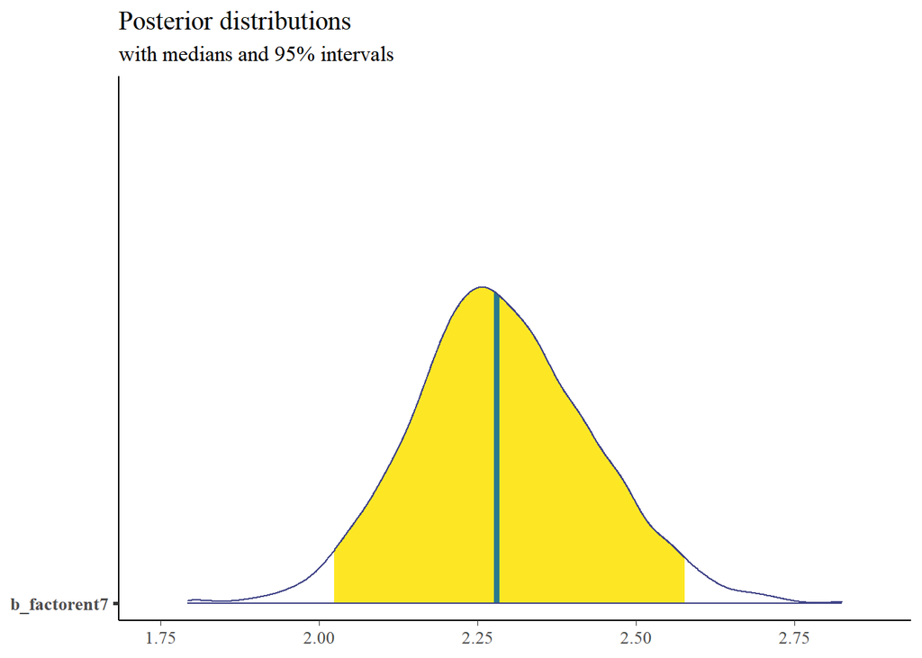

```r
plot_title <- ggtitle("Posterior distributions",
                      "with medians and 95% intervals")
mcmc_areas(M1,
           pars = c( "b_factorent7"),
           prob = 0.95) + plot_title
```

## Chequeos predictivos posteriores

Quisieramos saber si el modelo hace buenas predicciones de las proporciones población pobre y no pobre. Para ello podemos utilizar la función `pp_check`. Dado que se trata de una variable categórica vamos a solicitar una gráfica de barras.

Como puede apreciarse, el modelo hace un muy buen trabjo en predecir las proporciones de población pobre y no pobre.

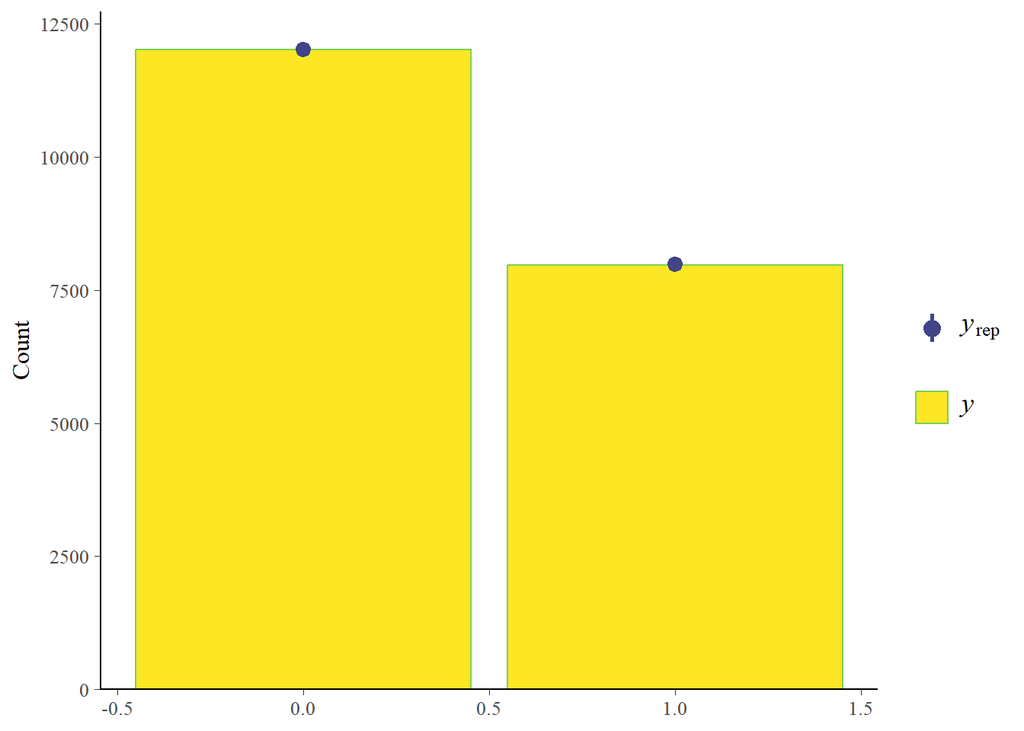

```r
pp_check(M1, ndraws = 11, type = "bars")
```

## Compración de modelos: Validacion cruzada.

NOTA: El comando `loo` toma mucho tiempo. Modera tus expectativas. Abajo utilizamos una aproximación con `loo_subsample`.

*The Pareto k estimate is a diagnostic for Pareto smoothed importance sampling (PSIS), which is used to compute components of elpd_loo. In importance-sampling LOO (the full posterior distribution is used as the proposal distribution). The Pareto k diagnostic estimates how far an individual leave-one-out distribution is from the full distribution. If leaving out an observation changes the posterior too much then importance sampling is not able to give reliable estimate. If k<0.5, then the corresponding component of elpd_loo is estimated with high accuracy. If 0.5<k<0.7 the accuracy is lower, but still ok. If k>0.7, then importance sampling is not able to provide useful estimate for that component/observation. Pareto k is also useful as a measure of influence of an observation. Highly influential observations have high k values. **Very high k values often indicate model misspecification, outliers or mistakes in data processing.***

```r
M.loo<-loo(M)
M1.loo<-loo(M1)
M.loo
```

```
##
## Computed from 4000 by 19999 log-likelihood matrix.
##
##          Estimate   SE
## elpd_loo -12418.6 48.3
## p_loo         5.1  0.1
## looic     24837.2 96.5
## ------
## MCSE of elpd_loo is 0.0.
## MCSE and ESS estimates assume MCMC draws (r_eff in [0.7, 1.3]).
##
## All Pareto k estimates are good (k < 0.7).
## See help('pareto-k-diagnostic') for details.
```

```r
M1.loo
```

```
##
## Computed from 4000 by 19999 log-likelihood matrix.
##
##          Estimate    SE
## elpd_loo -11329.4  62.6
## p_loo        40.0   0.3
## looic     22658.7 125.3
## ------
## MCSE of elpd_loo is 0.1.
## MCSE and ESS estimates assume MCMC draws (r_eff in [0.0, 2.3]).
##
## All Pareto k estimates are good (k < 0.7).
## See help('pareto-k-diagnostic') for details.
```

*When using loo_compare(), the returned matrix will have one row per model and several columns of estimates. The values in the elpd_diff and se_diff columns of the returned matrix are computed by making pairwise comparisons between each model and the model with the largest ELPD (the model in the first row). For this reason the elpd_diff column will always have the value 0 in the first row (i.e., the difference between the preferred model and itself) and negative values in subsequent rows for the remaining models.*

El modelo con el valor más bajo “elpd_diff” es el peor

```r
loo_compare(M1.loo,M.loo)
```

```
##    elpd_diff se_diff
## M1     0.0       0.0
## M  -1089.2      45.4
```

### LOO eficiente basado en n=400: loo_subsample

```r
fastloo<-loo_subsample(M)
fastloo1<-loo_subsample(M1)
loo_compare(fastloo1,fastloo)
```

[output not shown]

Gráficas con loo

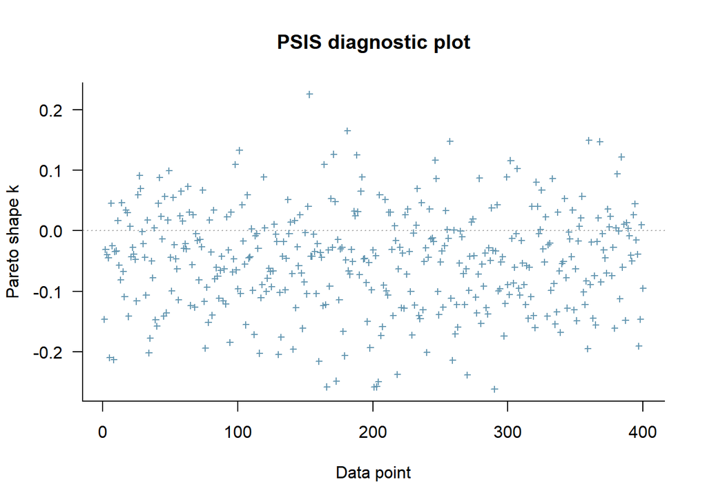

```r
plot(fastloo1)
```

## Multinivel

```r
M1.b<-brm(pobreza ~ 1 + factor(niv_edexpjh) + tamhogesc + factor(tam_loc) + (1 | ent),
        prior = c(set_prior("normal(0,10)", class = "b"),
                  set_prior("normal(0,5)", class = "sd")),
        family="bernoulli", chains=4, cores=14, iter=1500,  threads = threading(14, grainsize = 100),backend = "cmdstanr", data=D)
```

```
## Running MCMC with 4 chains, at most 14 in parallel, with 14 thread(s) per chain...
##
## Chain 1 Iteration:    1 / 1500 [  0%]  (Warmup)
## Chain 1 Iteration:  100 / 1500 [  6%]  (Warmup)
## Chain 1 Iteration:  200 / 1500 [ 13%]  (Warmup)
## Chain 1 Iteration:  300 / 1500 [ 20%]  (Warmup)
## Chain 1 Iteration:  400 / 1500 [ 26%]  (Warmup)
## Chain 1 Iteration:  500 / 1500 [ 33%]  (Warmup)
## Chain 1 Iteration:  600 / 1500 [ 40%]  (Warmup)
## Chain 1 Iteration:  700 / 1500 [ 46%]  (Warmup)
## Chain 1 Iteration:  751 / 1500 [ 50%]  (Sampling)
## Chain 1 Iteration:  850 / 1500 [ 56%]  (Sampling)
## Chain 1 Iteration:  950 / 1500 [ 63%]  (Sampling)
## Chain 1 Iteration: 1050 / 1500 [ 70%]  (Sampling)
## Chain 1 Iteration: 1150 / 1500 [ 76%]  (Sampling)
## Chain 1 Iteration: 1250 / 1500 [ 83%]  (Sampling)
## Chain 1 Iteration: 1350 / 1500 [ 90%]  (Sampling)
## Chain 1 Iteration: 1450 / 1500 [ 96%]  (Sampling)
## Chain 1 Iteration: 1500 / 1500 [100%]  (Sampling)
## Chain 2 Iteration:    1 / 1500 [  0%]  (Warmup)
## Chain 2 Iteration:  100 / 1500 [  6%]  (Warmup)
## Chain 2 Iteration:  200 / 1500 [ 13%]  (Warmup)
## Chain 2 Iteration:  300 / 1500 [ 20%]  (Warmup)
## Chain 2 Iteration:  400 / 1500 [ 26%]  (Warmup)
## Chain 2 Iteration:  500 / 1500 [ 33%]  (Warmup)
## Chain 2 Iteration:  600 / 1500 [ 40%]  (Warmup)
## Chain 2 Iteration:  700 / 1500 [ 46%]  (Warmup)
## Chain 2 Iteration:  751 / 1500 [ 50%]  (Sampling)
## Chain 2 Iteration:  850 / 1500 [ 56%]  (Sampling)
## Chain 2 Iteration:  950 / 1500 [ 63%]  (Sampling)
## Chain 2 Iteration: 1050 / 1500 [ 70%]  (Sampling)
## Chain 2 Iteration: 1150 / 1500 [ 76%]  (Sampling)
## Chain 2 Iteration: 1250 / 1500 [ 83%]  (Sampling)
## Chain 2 Iteration: 1350 / 1500 [ 90%]  (Sampling)
## Chain 2 Iteration: 1450 / 1500 [ 96%]  (Sampling)
## Chain 2 Iteration: 1500 / 1500 [100%]  (Sampling)
## Chain 3 Iteration:    1 / 1500 [  0%]  (Warmup)
## Chain 3 Iteration:  100 / 1500 [  6%]  (Warmup)
## Chain 3 Iteration:  200 / 1500 [ 13%]  (Warmup)
## Chain 3 Iteration:  300 / 1500 [ 20%]  (Warmup)
```

[output cut: 23 more lines]

```
## Chain 4 Iteration:  700 / 1500 [ 46%]  (Warmup)
## Chain 4 Iteration:  751 / 1500 [ 50%]  (Sampling)
## Chain 4 Iteration:  850 / 1500 [ 56%]  (Sampling)
## Chain 4 Iteration:  950 / 1500 [ 63%]  (Sampling)
## Chain 4 Iteration: 1050 / 1500 [ 70%]  (Sampling)
## Chain 4 Iteration: 1150 / 1500 [ 76%]  (Sampling)
## Chain 4 Iteration: 1250 / 1500 [ 83%]  (Sampling)
## Chain 4 Iteration: 1350 / 1500 [ 90%]  (Sampling)
## Chain 4 Iteration: 1450 / 1500 [ 96%]  (Sampling)
## Chain 4 Iteration: 1500 / 1500 [100%]  (Sampling)
## Chain 4 finished in 18.2 seconds.
##
## All 4 chains finished successfully.
## Mean chain execution time: 17.4 seconds.
## Total execution time: 79.1 seconds.
```

```r
summary(M1.b)
```

```
##  Family: bernoulli
##   Links: mu = logit
## Formula: pobreza ~ 1 + factor(niv_edexpjh) + tamhogesc + factor(tam_loc) + (1 | ent)
##    Data: D (Number of observations: 19999)
##   Draws: 4 chains, each with iter = 1500; warmup = 750; thin = 1;
##          total post-warmup draws = 3000
##
## Multilevel Hyperparameters:
## ~ent (Number of levels: 32)
##               Estimate Est.Error l-95% CI u-95% CI Rhat Bulk_ESS Tail_ESS
## sd(Intercept)     0.69      0.10     0.54     0.92 1.01      334      664
##
## Regression Coefficients:
##                    Estimate Est.Error l-95% CI u-95% CI Rhat Bulk_ESS Tail_ESS
## Intercept             -0.58      0.14    -0.88    -0.29 1.01      244      344
## factorniv_edexpjh1    -0.29      0.05    -0.38    -0.20 1.00     1380     1800
## factorniv_edexpjh2    -0.65      0.04    -0.73    -0.57 1.00     1269     1415
## factorniv_edexpjh3    -1.40      0.06    -1.51    -1.29 1.00     1464     1691
## factorniv_edexpjh4    -2.50      0.09    -2.68    -2.32 1.00     1571     1764
## tamhogesc              0.14      0.01     0.12     0.16 1.00     1640     1865
## factortam_loc2         0.44      0.06     0.33     0.55 1.01     1425     1916
## factortam_loc3         0.68      0.06     0.57     0.78 1.00     1190     1774
## factortam_loc4         0.23      0.04     0.15     0.31 1.00     1230     1783
##
## Draws were sampled using sample(hmc). For each parameter, Bulk_ESS
## and Tail_ESS are effective sample size measures, and Rhat is the potential
## scale reduction factor on split chains (at convergence, Rhat = 1).
```

A continuación graficamos las distribuciones posteriores del efecto aleatorio para cada entidad. Tenemos que hacer varias manipulaciones de las MCMC para poder hacerlo. Observamos las diferencias en efecto para los diferentes estados.

```r
ranef(M1.b, groups="ent", probs = 0.5)
```

```
## $ent
## , , Intercept
##
##       Estimate Est.Error         Q50
## 1  -0.77356831 0.1600074 -0.77049400
## 2  -0.97590374 0.1574829 -0.97665600
## 3  -0.94194645 0.1663749 -0.94488600
## 4   0.22299323 0.1572537  0.21949600
## 5  -0.93073914 0.1572025 -0.93124150
## 6  -0.32314270 0.1572012 -0.32619550
## 7   1.47683311 0.1669584  1.47486500
## 8  -0.31755959 0.1492928 -0.32001500
## 9  -0.17849812 0.1623321 -0.17581600
## 10 -0.14185465 0.1550940 -0.14166500
## 11  0.06417681 0.1495325  0.06285710
```

[output cut: 21 more lines]

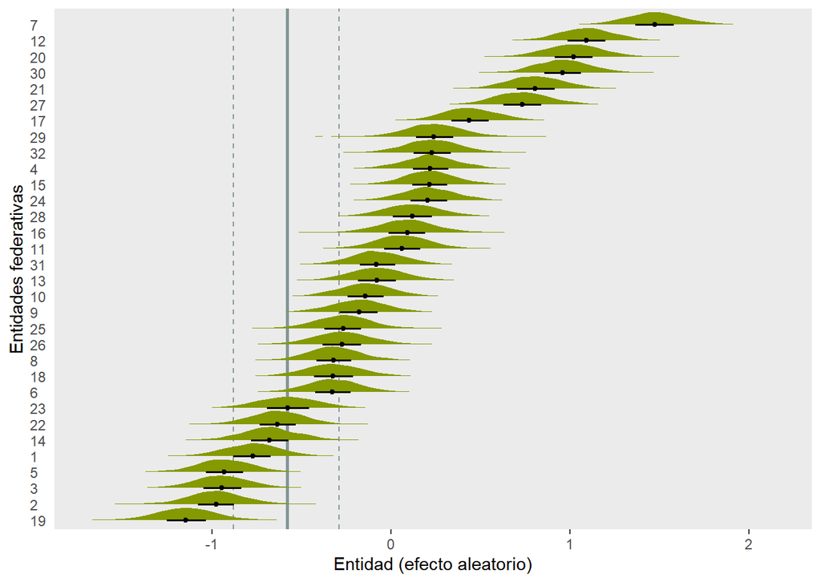

```r
library(stringr)

M1.b %>%
  spread_draws(r_ent[ent,]) %>%
  # add the grand mean to the group-specific deviations
  mutate(mu = r_ent) %>%
  ungroup() %>%
  mutate(ent = str_replace_all(ent, "[.]", " ")) %>%

  # plot
  ggplot(aes(x = mu, y = reorder(ent, mu))) +
  geom_vline(xintercept = fixef(M1.b)[1, 1], color = "#839496", size = 1) +
  geom_vline(xintercept = fixef(M1.b)[1, 3:4], color = "#839496", linetype = 2) +
  geom_halfeyeh(.width = .5, size = 2/3, fill = "#859900") +
  labs(x = expression("Entidad (efecto aleatorio)"),
       y = "Entidades federativas") +
  theme(panel.grid   = element_blank(),
        axis.ticks.y = element_blank(),
        axis.text.y  = element_text(hjust = 0),
        text = element_text(family = "Ubuntu"))
```

# Evaluación de modelos con cross-validation y loo

*The Pareto k estimate is a diagnostic for Pareto smoothed importance sampling (PSIS), which is used to compute components of elpd_loo. In importance-sampling LOO (the full posterior distribution is used as the proposal distribution). The Pareto k diagnostic estimates how far an individual leave-one-out distribution is from the full distribution. If leaving out an observation changes the posterior too much then importance sampling is not able to give reliable estimate. If k<0.5, then the corresponding component of elpd_loo is estimated with high accuracy. If 0.5<k<0.7 the accuracy is lower, but still ok. If k>0.7, then importance sampling is not able to provide useful estimate for that component/observation. Pareto k is also useful as a measure of influence of an observation. Highly influential observations have high k values. **Very high k values often indicate model misspecification, outliers or mistakes in data processing.***

```r
M1.b.loo<-loo(M1.b)
M1.b.loo
```

```
##
## Computed from 3000 by 19999 log-likelihood matrix.
##
##          Estimate    SE
## elpd_loo -11329.6  62.2
## p_loo        39.9   0.3
## looic     22659.2 124.3
## ------
## MCSE of elpd_loo is 0.1.
## MCSE and ESS estimates assume MCMC draws (r_eff in [0.6, 1.7]).
##
## All Pareto k estimates are good (k < 0.7).
## See help('pareto-k-diagnostic') for details.
```

*When using loo_compare(), the returned matrix will have one row per model and several columns of estimates. The values in the elpd_diff and se_diff columns of the returned matrix are computed by making pairwise comparisons between each model and the model with the largest ELPD (the model in the first row). For this reason the elpd_diff column will always have the value 0 in the first row (i.e., the difference between the preferred model and itself) and negative values in subsequent rows for the remaining models.*

El modelo con el valor más bajo “elpd_diff” es el peor

El modelo de referencia “0” es el mejor. La diferencia es trivial entre ambos.

```r
loo_compare(M1.loo,M1.b.loo,M.loo)
```

```
##      elpd_diff se_diff
## M1       0.0       0.0
## M1.b    -0.2       0.8
## M    -1089.2      45.4
```

## Pendientes aleatorias (al interior de cada estado)

```r
M1.c<-brm(pobreza ~ 1 + factor(niv_edexpjh) + tamhogesc + factor(tam_loc) + (1 + niv_edexpjh | ent),
        prior = c(set_prior("normal(0,10)", class = "b"),
                  set_prior("normal(0,5)", class = "sd")),
        family="bernoulli", chains=2, cores=14, iter=1500,  threads = threading(14, grainsize = 100),backend = "cmdstanr", data=D)
```

```
## Running MCMC with 2 chains, at most 14 in parallel, with 14 thread(s) per chain...
##
## Chain 1 Iteration:    1 / 1500 [  0%]  (Warmup)
## Chain 1 Iteration:  100 / 1500 [  6%]  (Warmup)
## Chain 2 Iteration:    1 / 1500 [  0%]  (Warmup)
## Chain 1 Iteration:  200 / 1500 [ 13%]  (Warmup)
## Chain 1 Iteration:  300 / 1500 [ 20%]  (Warmup)
## Chain 1 Iteration:  400 / 1500 [ 26%]  (Warmup)
## Chain 1 Iteration:  500 / 1500 [ 33%]  (Warmup)
## Chain 1 Iteration:  600 / 1500 [ 40%]  (Warmup)
## Chain 1 Iteration:  700 / 1500 [ 46%]  (Warmup)
## Chain 1 Iteration:  751 / 1500 [ 50%]  (Sampling)
## Chain 1 Iteration:  850 / 1500 [ 56%]  (Sampling)
## Chain 2 Iteration:  100 / 1500 [  6%]  (Warmup)
## Chain 1 Iteration:  950 / 1500 [ 63%]  (Sampling)
## Chain 2 Iteration:  200 / 1500 [ 13%]  (Warmup)
## Chain 1 Iteration: 1050 / 1500 [ 70%]  (Sampling)
## Chain 2 Iteration:  300 / 1500 [ 20%]  (Warmup)
## Chain 2 Iteration:  400 / 1500 [ 26%]  (Warmup)
## Chain 1 Iteration: 1150 / 1500 [ 76%]  (Sampling)
## Chain 2 Iteration:  500 / 1500 [ 33%]  (Warmup)
## Chain 2 Iteration:  600 / 1500 [ 40%]  (Warmup)
## Chain 1 Iteration: 1250 / 1500 [ 83%]  (Sampling)
## Chain 2 Iteration:  700 / 1500 [ 46%]  (Warmup)
## Chain 2 Iteration:  751 / 1500 [ 50%]  (Sampling)
## Chain 1 Iteration: 1350 / 1500 [ 90%]  (Sampling)
## Chain 2 Iteration:  850 / 1500 [ 56%]  (Sampling)
## Chain 1 Iteration: 1450 / 1500 [ 96%]  (Sampling)
## Chain 1 Iteration: 1500 / 1500 [100%]  (Sampling)
## Chain 1 finished in 55.2 seconds.
## Chain 2 Iteration:  950 / 1500 [ 63%]  (Sampling)
## Chain 2 Iteration: 1050 / 1500 [ 70%]  (Sampling)
## Chain 2 Iteration: 1150 / 1500 [ 76%]  (Sampling)
## Chain 2 Iteration: 1250 / 1500 [ 83%]  (Sampling)
## Chain 2 Iteration: 1350 / 1500 [ 90%]  (Sampling)
## Chain 2 Iteration: 1450 / 1500 [ 96%]  (Sampling)
## Chain 2 Iteration: 1500 / 1500 [100%]  (Sampling)
## Chain 2 finished in 53.4 seconds.
##
## Both chains finished successfully.
## Mean chain execution time: 54.3 seconds.
## Total execution time: 83.8 seconds.
```

```r
summary(M1.c)
```

```
##  Family: bernoulli
##   Links: mu = logit
## Formula: pobreza ~ 1 + factor(niv_edexpjh) + tamhogesc + factor(tam_loc) + (1 + niv_edexpjh | ent)
##    Data: D (Number of observations: 19999)
##   Draws: 2 chains, each with iter = 1500; warmup = 750; thin = 1;
##          total post-warmup draws = 1500
##
## Multilevel Hyperparameters:
## ~ent (Number of levels: 32)
##                            Estimate Est.Error l-95% CI u-95% CI Rhat Bulk_ESS
## sd(Intercept)                  0.77      0.11     0.58     1.01 1.02      310
## sd(niv_edexpjh)                0.09      0.02     0.05     0.14 1.01      634
## cor(Intercept,niv_edexpjh)    -0.63      0.17    -0.91    -0.26 1.00     1021
##                            Tail_ESS
## sd(Intercept)                   400
## sd(niv_edexpjh)                 801
## cor(Intercept,niv_edexpjh)      650
##
## Regression Coefficients:
##                    Estimate Est.Error l-95% CI u-95% CI Rhat Bulk_ESS Tail_ESS
## Intercept             -0.61      0.15    -0.92    -0.30 1.00      350      488
## factorniv_edexpjh1    -0.29      0.05    -0.38    -0.19 1.00     1331     1242
## factorniv_edexpjh2    -0.65      0.06    -0.76    -0.53 1.00      848     1050
## factorniv_edexpjh3    -1.38      0.08    -1.54    -1.22 1.00      804     1010
## factorniv_edexpjh4    -2.48      0.12    -2.71    -2.25 1.00      906      986
## tamhogesc              0.14      0.01     0.12     0.16 1.00     2562      770
## factortam_loc2         0.45      0.06     0.34     0.56 1.00     1791     1281
## factortam_loc3         0.68      0.05     0.58     0.79 1.00     1964     1290
## factortam_loc4         0.23      0.04     0.15     0.31 1.00     1774     1304
##
## Draws were sampled using sample(hmc). For each parameter, Bulk_ESS
## and Tail_ESS are effective sample size measures, and Rhat is the potential
## scale reduction factor on split chains (at convergence, Rhat = 1).
```

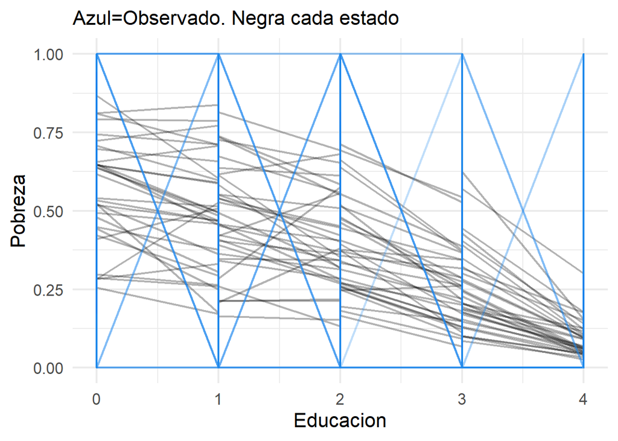

```r
M1.c$data %>%
  bind_cols(as_tibble(fitted(M1.c))) %>%
  ggplot() +
  geom_line(aes(x = niv_edexpjh, y = Estimate, group = ent), size = .75, alpha = .30) +
  geom_line(aes(x = niv_edexpjh, y = pobreza, group = ent), size = .75, alpha = .15, color = "dodgerblue2") +
  labs(x = "Educacion",
       y = "Pobreza",
       subtitle = "Azul=Observado. Negra cada estado") +
  theme_minimal(base_size = 16) +
  theme(plot.title = element_text(hjust = .5))
```

```r
M1.c.loo<-loo(M1.c)
loo_compare(M1.b.loo, M1.c.loo)
```

```
##      elpd_diff se_diff
## M1.c  0.0       0.0
## M1.b -9.6       4.7
```

# Predicción

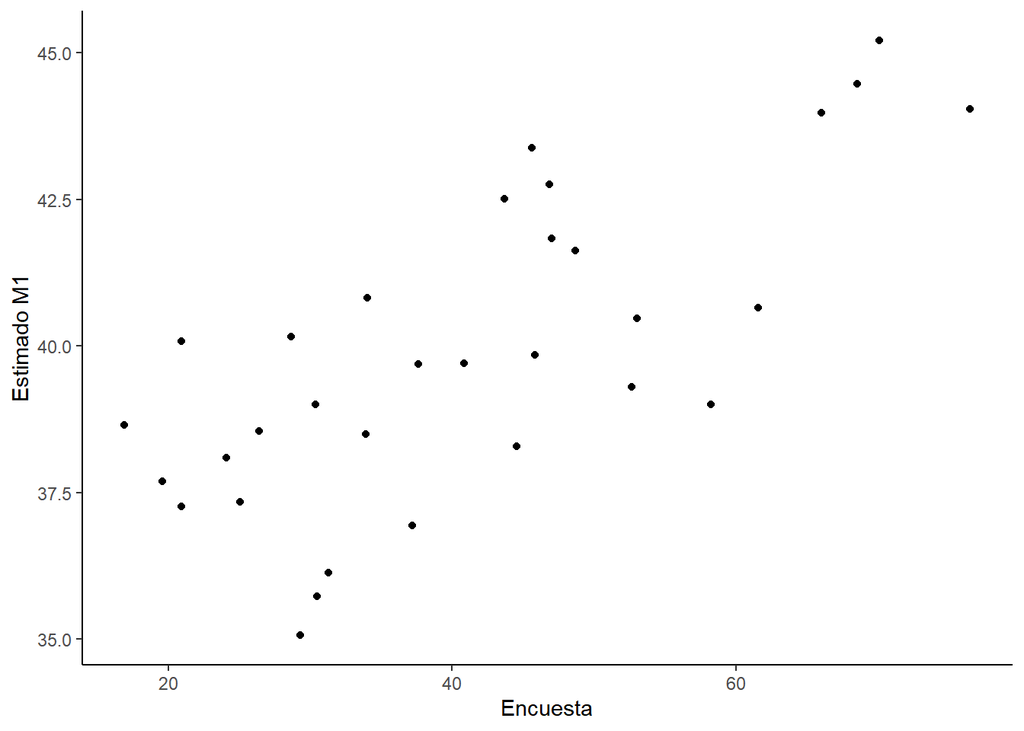

```r
D$prM1<-predict(M, newdata=D ,ndraws=300)
D$prM1.c<-predict(M1.c, newdata=D ,ndraws=300)

D %>% group_by(ent) %>% summarise(SPent=mean(pobreza, na.rm=T), M1Pent=mean(prM1[,1], na.rm=T),
                                  M1.cPent=mean(prM1.c[,1], na.rm=T)) -> Prent

ggplot(Prent, aes(SPent*100, M1Pent*100)) + geom_point() + theme_classic() + labs(y="Estimado M1", x="Encuesta")
```

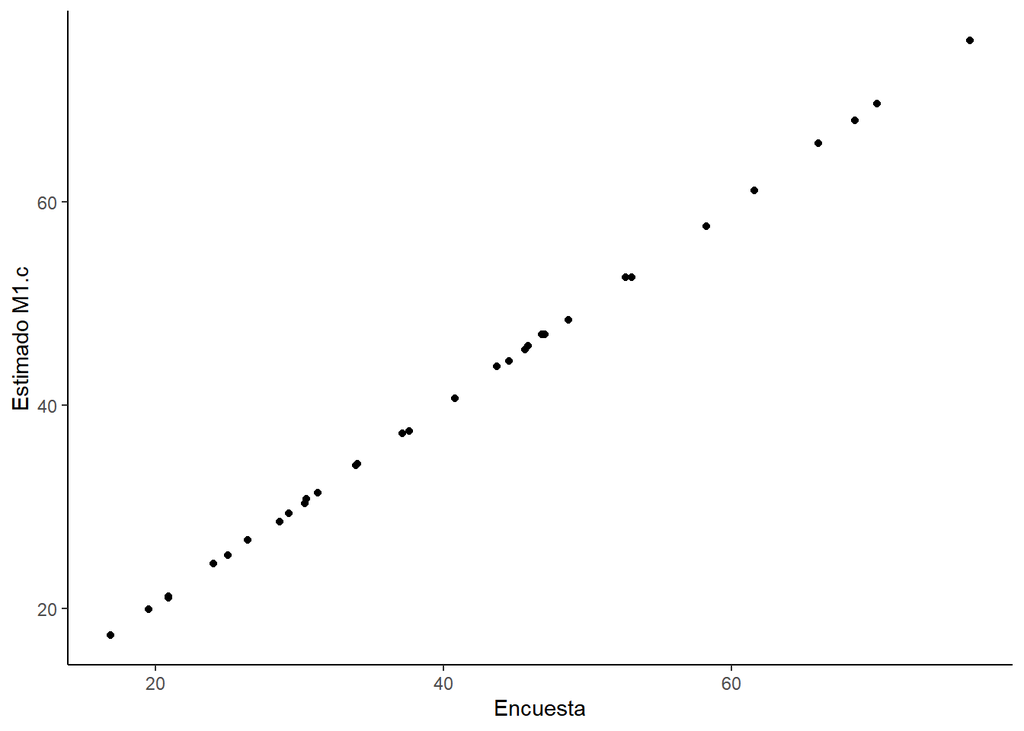

```r
ggplot(Prent, aes(SPent*100, M1.cPent*100)) + geom_point() + theme_classic() + labs(y="Estimado M1.c", x="Encuesta")
```

## Comparamos con regresiones por separado

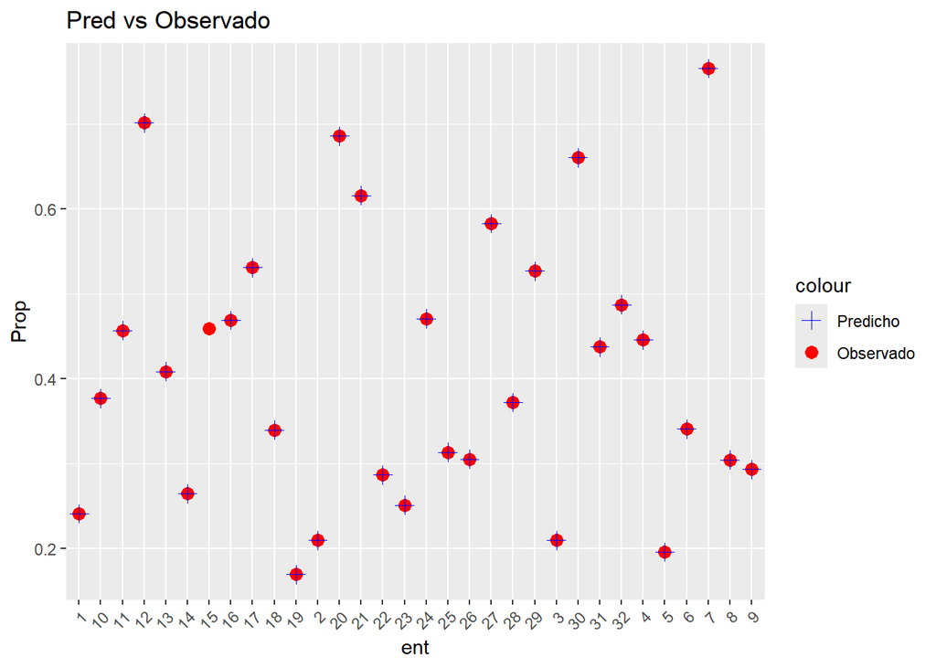

```r
logit_model <- function(D) {
  glm(pobreza ~ factor(niv_edexpjh) + tamhogesc + factor(tam_loc), data = D, family = binomial)
}


models <- by(D, D$ent, logit_model)


predict_mean_prob <- function(model) {
  probs <- predict(model, type = "response")
  mean_prob <- mean(probs)
  return(mean_prob)
}


mean_probs <- sapply(models, predict_mean_prob)


observed_means <- tapply(D$pobreza, D$ent, mean)

mean_values_df <- data.frame(ent = names(mean_probs),
                             predicted_mean = mean_probs,
                             observed_mean = observed_means)

ggplot(mean_values_df, aes(x = ent)) +
  geom_point(aes(y = predicted_mean, color = "Predicho"), size = 3) +
  geom_point(aes(y = observed_mean, color = "Observado"), size = 3, shape = 3) +
  labs(x = "ent", y = "Prop", title = "Pred vs Observado") +
  scale_color_manual(values = c("blue", "red"), labels = c("Predicho", "Observado")) +
  theme(axis.text.x = element_text(angle = 45, hjust = 1))
```

# Segundo ejemplo: Ordinal v multinomial

Cambiamos a `cumulative("logit")`

```r
D$i_privacion1<-D$i_privacion+1

M2<-brm(i_privacion1 ~ 1 + factor(niv_edexpjh) + tamhogesc + factor(tam_loc) + (1 | ent),
        prior = c(set_prior("normal(0,10)", class = "b"),
                  set_prior("normal(0,5)", class = "sd")),
        family=cumulative("logit", threshold="flexible"), chains=2, cores=14, iter=2000,  threads = threading(14, grainsize = 100),backend = "cmdstanr", data=D)
```

```
## Running MCMC with 2 chains, at most 14 in parallel, with 14 thread(s) per chain...
##
## Chain 1 Iteration:    1 / 2000 [  0%]  (Warmup)
## Chain 2 Iteration:    1 / 2000 [  0%]  (Warmup)
## Chain 1 Iteration:  100 / 2000 [  5%]  (Warmup)
## Chain 1 Iteration:  200 / 2000 [ 10%]  (Warmup)
## Chain 2 Iteration:  100 / 2000 [  5%]  (Warmup)
## Chain 1 Iteration:  300 / 2000 [ 15%]  (Warmup)
## Chain 2 Iteration:  200 / 2000 [ 10%]  (Warmup)
## Chain 1 Iteration:  400 / 2000 [ 20%]  (Warmup)
## Chain 2 Iteration:  300 / 2000 [ 15%]  (Warmup)
## Chain 2 Iteration:  400 / 2000 [ 20%]  (Warmup)
## Chain 1 Iteration:  500 / 2000 [ 25%]  (Warmup)
## Chain 2 Iteration:  500 / 2000 [ 25%]  (Warmup)
## Chain 1 Iteration:  600 / 2000 [ 30%]  (Warmup)
## Chain 2 Iteration:  600 / 2000 [ 30%]  (Warmup)
## Chain 1 Iteration:  700 / 2000 [ 35%]  (Warmup)
## Chain 2 Iteration:  700 / 2000 [ 35%]  (Warmup)
## Chain 1 Iteration:  800 / 2000 [ 40%]  (Warmup)
## Chain 1 Iteration:  900 / 2000 [ 45%]  (Warmup)
## Chain 2 Iteration:  800 / 2000 [ 40%]  (Warmup)
## Chain 2 Iteration:  900 / 2000 [ 45%]  (Warmup)
## Chain 1 Iteration: 1000 / 2000 [ 50%]  (Warmup)
## Chain 1 Iteration: 1001 / 2000 [ 50%]  (Sampling)
## Chain 2 Iteration: 1000 / 2000 [ 50%]  (Warmup)
## Chain 2 Iteration: 1001 / 2000 [ 50%]  (Sampling)
## Chain 1 Iteration: 1100 / 2000 [ 55%]  (Sampling)
## Chain 2 Iteration: 1100 / 2000 [ 55%]  (Sampling)
## Chain 1 Iteration: 1200 / 2000 [ 60%]  (Sampling)
## Chain 2 Iteration: 1200 / 2000 [ 60%]  (Sampling)
## Chain 1 Iteration: 1300 / 2000 [ 65%]  (Sampling)
## Chain 2 Iteration: 1300 / 2000 [ 65%]  (Sampling)
## Chain 1 Iteration: 1400 / 2000 [ 70%]  (Sampling)
## Chain 2 Iteration: 1400 / 2000 [ 70%]  (Sampling)
## Chain 1 Iteration: 1500 / 2000 [ 75%]  (Sampling)
## Chain 2 Iteration: 1500 / 2000 [ 75%]  (Sampling)
## Chain 1 Iteration: 1600 / 2000 [ 80%]  (Sampling)
## Chain 2 Iteration: 1600 / 2000 [ 80%]  (Sampling)
## Chain 1 Iteration: 1700 / 2000 [ 85%]  (Sampling)
## Chain 2 Iteration: 1700 / 2000 [ 85%]  (Sampling)
## Chain 1 Iteration: 1800 / 2000 [ 90%]  (Sampling)
## Chain 2 Iteration: 1800 / 2000 [ 90%]  (Sampling)
## Chain 1 Iteration: 1900 / 2000 [ 95%]  (Sampling)
## Chain 2 Iteration: 1900 / 2000 [ 95%]  (Sampling)
## Chain 1 Iteration: 2000 / 2000 [100%]  (Sampling)
## Chain 1 finished in 206.9 seconds.
## Chain 2 Iteration: 2000 / 2000 [100%]  (Sampling)
## Chain 2 finished in 195.1 seconds.
##
## Both chains finished successfully.
## Mean chain execution time: 201.0 seconds.
## Total execution time: 225.6 seconds.
```

```r
summary(M2)
```

```
##  Family: cumulative
##   Links: mu = logit; disc = identity
## Formula: i_privacion1 ~ 1 + factor(niv_edexpjh) + tamhogesc + factor(tam_loc) + (1 | ent)
##    Data: D (Number of observations: 19999)
##   Draws: 2 chains, each with iter = 2000; warmup = 1000; thin = 1;
##          total post-warmup draws = 2000
##
## Multilevel Hyperparameters:
## ~ent (Number of levels: 32)
##               Estimate Est.Error l-95% CI u-95% CI Rhat Bulk_ESS Tail_ESS
## sd(Intercept)     0.56      0.08     0.43     0.74 1.03      210      379
##
## Regression Coefficients:
##                    Estimate Est.Error l-95% CI u-95% CI Rhat Bulk_ESS Tail_ESS
## Intercept[1]          -1.32      0.11    -1.53    -1.10 1.01      228      352
## Intercept[2]           0.28      0.11     0.08     0.50 1.01      228      324
## Intercept[3]           1.73      0.11     1.53     1.96 1.01      234      327
## Intercept[4]           3.13      0.11     2.92     3.36 1.01      248      385
## Intercept[5]           4.79      0.12     4.55     5.04 1.01      281      421
## Intercept[6]           6.82      0.19     6.46     7.20 1.00      562      913
## factorniv_edexpjh1    -0.65      0.04    -0.73    -0.58 1.00     1301     1417
## factorniv_edexpjh2    -1.11      0.04    -1.18    -1.04 1.00      975     1257
## factorniv_edexpjh3    -1.67      0.05    -1.76    -1.57 1.00     1145     1334
## factorniv_edexpjh4    -2.21      0.06    -2.32    -2.10 1.00     1245     1161
## tamhogesc              0.09      0.01     0.08     0.11 1.00     2157     1415
## factortam_loc2         0.35      0.05     0.26     0.44 1.00     1423     1302
## factortam_loc3         0.63      0.04     0.54     0.71 1.00     1162     1259
## factortam_loc4         1.07      0.04     1.00     1.14 1.00     1162     1170
##
## Further Distributional Parameters:
##      Estimate Est.Error l-95% CI u-95% CI Rhat Bulk_ESS Tail_ESS
## disc     1.00      0.00     1.00     1.00   NA       NA       NA
##
## Draws were sampled using sample(hmc). For each parameter, Bulk_ESS
## and Tail_ESS are effective sample size measures, and Rhat is the potential
## scale reduction factor on split chains (at convergence, Rhat = 1).
```

En este caso `pp_check` lo hacemos con barras puesto que se trata de una variable de grupos

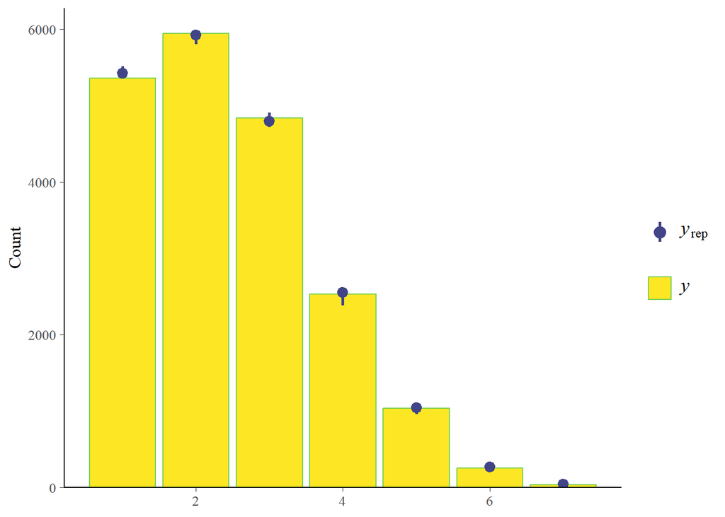

```r
pp_check(M2, nreps = 10, type = "bars")
```

# Multinomial

- Este modelo es sumamente pesado: predictores X categorías con efectos aleatorios X categorías.
- Este modelo necesita prior débiles para producir resultados razonables.
- Intenten estimar este modelo con ML.

```r
D$i_privacion1<-as.factor(D$i_privacion1)
#Ds<-sample_n(D,10000)

M3<-brm(i_privacion1 ~ 1  + factor(niv_edexpjh) + tamhogesc + factor(tam_loc) + (1 | ent),
         prior = c(set_prior("normal(0,5)", class="b", dpar = "mu2"),
                            set_prior("normal(0,5)", class="b", dpar = "mu3"),
                                set_prior("normal(0,5)", class="sd", dpar = "mu3"),
                                set_prior("normal(0,5)", class="sd", dpar = "mu2"),
                            set_prior("normal(0,5)", class="b", dpar = "mu4"),
                            set_prior("normal(0,5)", class="b", dpar = "mu5"),
                            set_prior("normal(0,5)", class="b", dpar = "mu6"),
                            set_prior("normal(0,5)", class="b", dpar = "mu7")),
        family = categorical(link = "logit"), chains=2, cores=2, iter=1500,  threads = threading(14, grainsize = 100),backend = "cmdstanr", data=D)
```

```
## Running MCMC with 2 parallel chains, with 14 thread(s) per chain...
##
## Chain 1 Iteration:    1 / 1500 [  0%]  (Warmup)
## Chain 2 Iteration:    1 / 1500 [  0%]  (Warmup)
## Chain 1 Iteration:  100 / 1500 [  6%]  (Warmup)
## Chain 1 Iteration:  200 / 1500 [ 13%]  (Warmup)
## Chain 1 Iteration:  300 / 1500 [ 20%]  (Warmup)
## Chain 1 Iteration:  400 / 1500 [ 26%]  (Warmup)
## Chain 2 Iteration:  100 / 1500 [  6%]  (Warmup)
## Chain 1 Iteration:  500 / 1500 [ 33%]  (Warmup)
## Chain 1 Iteration:  600 / 1500 [ 40%]  (Warmup)
## Chain 2 Iteration:  200 / 1500 [ 13%]  (Warmup)
## Chain 1 Iteration:  700 / 1500 [ 46%]  (Warmup)
## Chain 2 Iteration:  300 / 1500 [ 20%]  (Warmup)
## Chain 1 Iteration:  751 / 1500 [ 50%]  (Sampling)
## Chain 2 Iteration:  400 / 1500 [ 26%]  (Warmup)
## Chain 1 Iteration:  850 / 1500 [ 56%]  (Sampling)
## Chain 1 Iteration:  950 / 1500 [ 63%]  (Sampling)
## Chain 2 Iteration:  500 / 1500 [ 33%]  (Warmup)
## Chain 1 Iteration: 1050 / 1500 [ 70%]  (Sampling)
## Chain 2 Iteration:  600 / 1500 [ 40%]  (Warmup)
## Chain 1 Iteration: 1150 / 1500 [ 76%]  (Sampling)
## Chain 2 Iteration:  700 / 1500 [ 46%]  (Warmup)
## Chain 2 Iteration:  751 / 1500 [ 50%]  (Sampling)
## Chain 1 Iteration: 1250 / 1500 [ 83%]  (Sampling)
## Chain 2 Iteration:  850 / 1500 [ 56%]  (Sampling)
## Chain 1 Iteration: 1350 / 1500 [ 90%]  (Sampling)
## Chain 1 Iteration: 1450 / 1500 [ 96%]  (Sampling)
## Chain 2 Iteration:  950 / 1500 [ 63%]  (Sampling)
## Chain 1 Iteration: 1500 / 1500 [100%]  (Sampling)
## Chain 1 finished in 179.0 seconds.
## Chain 2 Iteration: 1050 / 1500 [ 70%]  (Sampling)
## Chain 2 Iteration: 1150 / 1500 [ 76%]  (Sampling)
## Chain 2 Iteration: 1250 / 1500 [ 83%]  (Sampling)
## Chain 2 Iteration: 1350 / 1500 [ 90%]  (Sampling)
## Chain 2 Iteration: 1450 / 1500 [ 96%]  (Sampling)
## Chain 2 Iteration: 1500 / 1500 [100%]  (Sampling)
## Chain 2 finished in 191.8 seconds.
##
## Both chains finished successfully.
## Mean chain execution time: 185.4 seconds.
## Total execution time: 222.5 seconds.
```

Claramente necesita más tiempo.

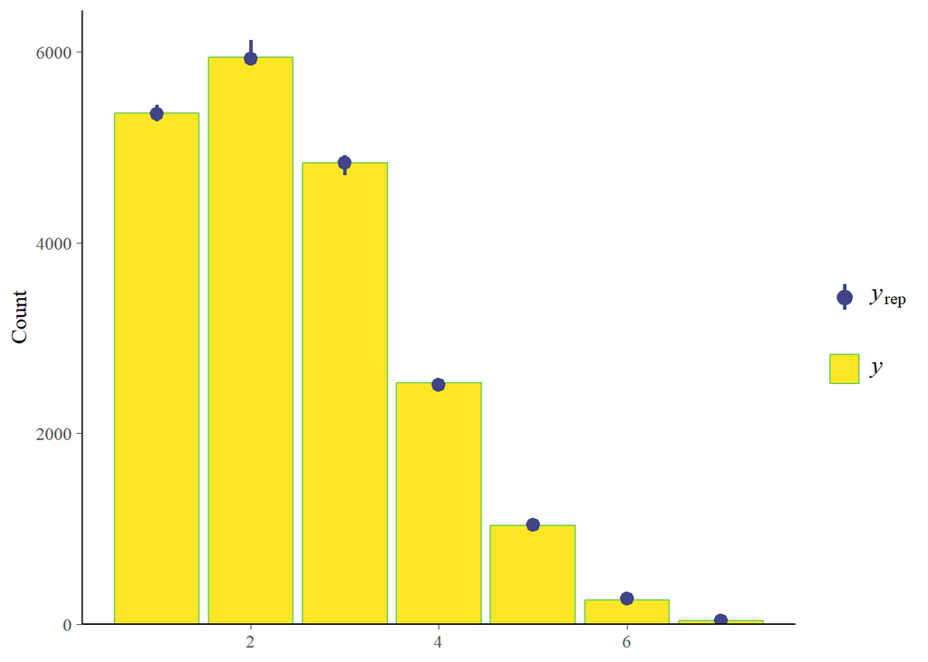

```r
pp_check(M3, nreps = 10, type = "bars")
```

¿Qué modelo es mejor el ordinal o el multinomial?

```r
M2.loo<-loo(M2)
M3.loo<-loo(M3)
M2.loo
```

```
##
## Computed from 2000 by 19999 log-likelihood matrix.
##
##          Estimate    SE
## elpd_loo -27429.7  96.8
## p_loo        45.4   0.3
## looic     54859.4 193.5
## ------
## MCSE of elpd_loo is 0.1.
## MCSE and ESS estimates assume MCMC draws (r_eff in [0.6, 1.9]).
##
## All Pareto k estimates are good (k < 0.7).
## See help('pareto-k-diagnostic') for details.
```

```r
M3.loo
```

```
##
## Computed from 1500 by 19999 log-likelihood matrix.
##
##          Estimate    SE
## elpd_loo -27327.8  96.9
## p_loo       207.6   4.7
## looic     54655.7 193.8
## ------
## MCSE of elpd_loo is 0.4.
## MCSE and ESS estimates assume MCMC draws (r_eff in [0.2, 3.0]).
##
## All Pareto k estimates are good (k < 0.69).
## See help('pareto-k-diagnostic') for details.
```